# Prediction of Barbell Lifts by Personal Activity Devices

Ertugrul Dalgic

June 2015

This report is based on the analysis of a dataset built based on the mesurements taken from the personal activity devices such as Jawbone Up, Nike FuelBand, or Fitbit.

5 different ways of barbell lifts (denoted as A,B,C,D or E in the classe column), are predicted by machine learning algorithms applied on more than 150 mearument variables. First, I read the training dataset and have a general look at it;

```r
trainpml <- read.csv('pml-training.csv',na.strings=c('','NA'))
dim(trainpml)
```

```
## [1] 19622   160
```

The dataset has a large number of variables which we can use to make predictions. However there are missing values. I need to have a better idea of how many missing variables there are;

```r
nomissing <- sapply(1:ncol(trainpml),function(x) sum(is.na(trainpml[,x])))
print(nomissing)
```

```
##   [1]     0     0     0     0     0     0     0     0     0     0     0
##  [12] 19216 19216 19216 19216 19216 19216 19216 19216 19216 19216 19216
##  [23] 19216 19216 19216 19216 19216 19216 19216 19216 19216 19216 19216
##  [34] 19216 19216 19216     0     0     0     0     0     0     0     0
##  [45]     0     0     0     0     0 19216 19216 19216 19216 19216 19216
##  [56] 19216 19216 19216 19216     0     0     0     0     0     0     0
##  [67]     0     0 19216 19216 19216 19216 19216 19216 19216 19216 19216
##  [78] 19216 19216 19216 19216 19216 19216     0     0     0 19216 19216
##  [89] 19216 19216 19216 19216 19216 19216 19216 19216 19216 19216 19216
## [100] 19216 19216     0 19216 19216 19216 19216 19216 19216 19216 19216
## [111] 19216 19216     0     0     0     0     0     0     0     0     0
## [122]     0     0     0 19216 19216 19216 19216 19216 19216 19216 19216
## [133] 19216 19216 19216 19216 19216 19216 19216     0 19216 19216 19216
## [144] 19216 19216 19216 19216 19216 19216 19216     0     0     0     0
## [155]     0     0     0     0     0     0
```

Most of the columns have 19216 missing values. Considering that the total number of rows is 19622, the majority of their values are missing so these columns are not useful for our analysis; so they can be removed. Also, The first column is just an index and the second column is the name of the participant so they are not useful for the prediction so they could also be removed. Furthermore, the 3rd, 4th, 5th and 6th columns are for dates which is also not a proper predictor for the current analysis, so they could also be removed. Finally the 7th column, which is names a num_window also seems to be irrelevant for making a prediction of the classe variable so it can also be removed.

```r
selectcol <- nomissing == 0
selectcol[1:7] = FALSE
tpml <- trainpml[,selectcol]
dim(tpml)
```

```
## [1] 19622    53
```

Looking at the names of the variables; there are four categories; belt, arm, dumbbell and forearm. There are too many variables (as predictors for machine learning algorithms). In order to understand which ones could be better at differentiating between the different classes I make a summarization of the data and look at an heatmap to see which variables differ between classes;

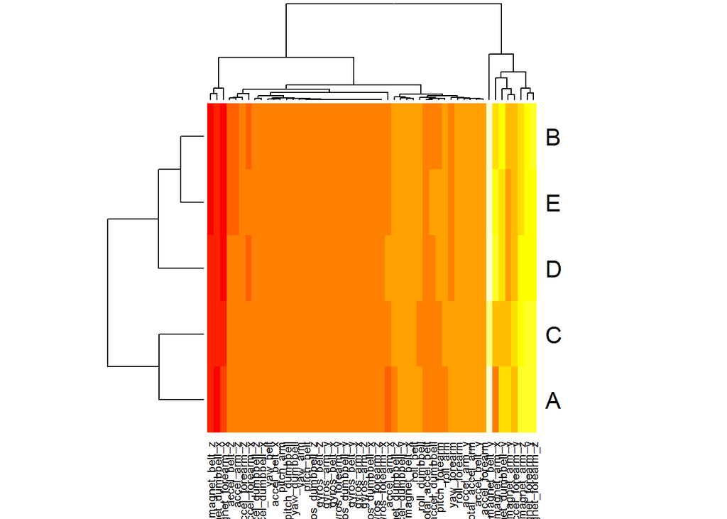

```r
tpmlA<-tpml[tpml$classe=='A',]
tpmlB<-tpml[tpml$classe=='B',]
tpmlC<-tpml[tpml$classe=='C',]
tpmlD<-tpml[tpml$classe=='D',]
tpmlE<-tpml[tpml$classe=='E',]
meanvals <- rbind(apply(tpmlA[1:52],2,mean),apply(tpmlB[1:52],2,mean),apply(tpmlC[1:52],2,mean),apply(tpmlD[1:52],2,mean),apply(tpmlE[1:52],2,mean))
rownames(meanvals)=c('A','B','C','D','E')
heatmap(as.matrix(meanvals))
```

```r
library(dplyr)
spml <- select(tpml,magnet_forearm_x,accel_belt_z,accel_arm_z,accel_forearm_z,accel_forearm_x,gyros_forearm_x,accel_arm_x,magnet_dumbbell_z,roll_dumbbell,total_accel_dumbbell,pitch_forearm,roll_arm,yaw_forearm,magnet_belt_y,magnet_arm_x,magnet_dumbbell_y,magnet_arm_y,accel_forearm_y,magnet_arm_z,classe)
dim(spml)
```

```
## [1] 19622    20
```

These variables are appropriate for a tree based machine learning algorithm since it can go like if magnet_arm_x is higher than a threshold then classe A can be selected and for a lower treshold classe B or C can be selected. Random forest algorithm will be my choice as the tree approach should be combined with bootstrapping in order to improve the accuracy. So, cross validation will be done automatically by bootstrapping (randomization of variables with replacement). Since the dataset is very large (containing 19622 rows), I can select 50% of it for training and the remaning for testing.

```r
library(caret)
seltr <- createDataPartition(y=spml$classe,p=0.5,list=FALSE)
trs <- spml[seltr,]
tes <- spml[-seltr,]
pmlrf <- train(classe~.,data=trs,method='rf',prox=TRUE)
prd <- predict(pmlrf,tes)
confusionMatrix(prd,tes$classe)
```

```
## Confusion Matrix and Statistics
##
##           Reference
## Prediction    A    B    C    D    E
##          A 2779   46    2   10    2
##          B    7 1804   30    1    4
##          C    2   34 1664   58    9
##          D    2    5   12 1536   10
##          E    0    9    3    3 1778
##
## Overall Statistics
##
##                Accuracy : 0.9746
##                  95% CI : (0.9713, 0.9776)
##     No Information Rate : 0.2844
##     P-Value [Acc > NIR] : < 2.2e-16
##
##                   Kappa : 0.9679
##  Mcnemar's Test P-Value : 1.312e-12
##
## Statistics by Class:
##
##                      Class: A Class: B Class: C Class: D Class: E
## Sensitivity            0.9961   0.9505   0.9725   0.9552   0.9861
## Specificity            0.9915   0.9947   0.9873   0.9965   0.9981
## Pos Pred Value         0.9789   0.9772   0.9417   0.9815   0.9916
## Neg Pred Value         0.9984   0.9882   0.9942   0.9913   0.9969
## Prevalence             0.2844   0.1935   0.1744   0.1639   0.1838
## Detection Rate         0.2833   0.1839   0.1696   0.1566   0.1812
## Detection Prevalence   0.2894   0.1882   0.1801   0.1595   0.1828
## Balanced Accuracy      0.9938   0.9726   0.9799   0.9758   0.9921
```

```r
table(prd,tes$classe)
```

```
##
## prd    A    B    C    D    E
##   A 2779   46    2   10    2
##   B    7 1804   30    1    4
##   C    2   34 1664   58    9
##   D    2    5   12 1536   10
##   E    0    9    3    3 1778
```